# RMarkdown Teaser

Workshop: Einführung in R

28.06.2022

## Markdown

### R Markdown Dokument

Das hier ist ein *R Markdown* Dokument. Es kann R Code ausführen und die Ergebnisse darstellen. Damit lassen sich z.B. automatisierte Berichte erzeugen, die mit neuen Daten vorgefertige Analysen ausführen.

### Formatierung

Mit ein paar einfachen Tricks kann man ein schönes und ev. interaktives **HTML- oder pdf-Dokument** erstellen.  
Z.B. mit `# Überschrift` bzw. `## Überschrift` kann man Überschriften in unterschiedlicher Größe erzeugen.

### Bilder

Es lassen sich auch Bilder integrieren.

[figure not shown]

### Codeblöcke

Man kann Codeblöcke anzeigen:

```r
# Das ist ein R Codeblock
# Der Code hier funktioniert und liefert einen Output

radius <- 3
flaeche <- radius ^ 2 * pi
```

Ein Kreis mit Radius 3cm hat die Fläche 28.2743339cm².

### Schöne Tabellen

| Sepal.Length | Sepal.Width | Petal.Length | Petal.Width | Species |
| --- | --- | --- | --- | --- |
| 5.1 | 3.5 | 1.4 | 0.2 | setosa |
| 4.9 | 3.0 | 1.4 | 0.2 | setosa |
| 4.7 | 3.2 | 1.3 | 0.2 | setosa |
| 4.6 | 3.1 | 1.5 | 0.2 | setosa |
| 5.0 | 3.6 | 1.4 | 0.2 | setosa |
| 5.4 | 3.9 | 1.7 | 0.4 | setosa |

## Beispieldatensatz

### Iris Beispieldaten

Der ‘iris’ Datensatz beinhaltet 150 Messungen der Blattlängen und -breiten von 3 verschiedenen Lilienspezies.  
Er ist in RStudio integriert und kann direkt verwendet werden.

Sepal und Petal sind verschiedene Blattarten:

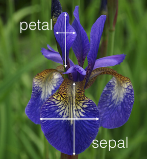

Iris

.

Ein erster Überblick über die Daten:

```r
# head() zeigt die ersten 6 Reihen oder Einzelwerte an:
head(iris)
```

```
##   Sepal.Length Sepal.Width Petal.Length Petal.Width Species
## 1          5.1         3.5          1.4         0.2  setosa
## 2          4.9         3.0          1.4         0.2  setosa
## 3          4.7         3.2          1.3         0.2  setosa
## 4          4.6         3.1          1.5         0.2  setosa
## 5          5.0         3.6          1.4         0.2  setosa
## 6          5.4         3.9          1.7         0.4  setosa
```

```r
# summary() berechnet für jede Spalte Minimum, Maximum, Quartile, Mean, Median:
summary(iris)
```

```
##   Sepal.Length    Sepal.Width     Petal.Length    Petal.Width
##  Min.   :4.300   Min.   :2.000   Min.   :1.000   Min.   :0.100
##  1st Qu.:5.100   1st Qu.:2.800   1st Qu.:1.600   1st Qu.:0.300
##  Median :5.800   Median :3.000   Median :4.350   Median :1.300
##  Mean   :5.843   Mean   :3.057   Mean   :3.758   Mean   :1.199
##  3rd Qu.:6.400   3rd Qu.:3.300   3rd Qu.:5.100   3rd Qu.:1.800
##  Max.   :7.900   Max.   :4.400   Max.   :6.900   Max.   :2.500
##        Species
##  setosa    :50
##  versicolor:50
##  virginica :50
##
##
##
```

```r
# str() zeigt die Datenstruktur der Variablen an
str(iris)
```

```
## 'data.frame':    150 obs. of  5 variables:
##  $ Sepal.Length: num  5.1 4.9 4.7 4.6 5 5.4 4.6 5 4.4 4.9 ...
##  $ Sepal.Width : num  3.5 3 3.2 3.1 3.6 3.9 3.4 3.4 2.9 3.1 ...
##  $ Petal.Length: num  1.4 1.4 1.3 1.5 1.4 1.7 1.4 1.5 1.4 1.5 ...
##  $ Petal.Width : num  0.2 0.2 0.2 0.2 0.2 0.4 0.3 0.2 0.2 0.1 ...
##  $ Species     : Factor w/ 3 levels "setosa","versicolor",..: 1 1 1 1 1 1 1 1 1 1 ...
```

## Grafiken

### Grafiken

In R kann man schnell und einfach Grafiken erstellen:

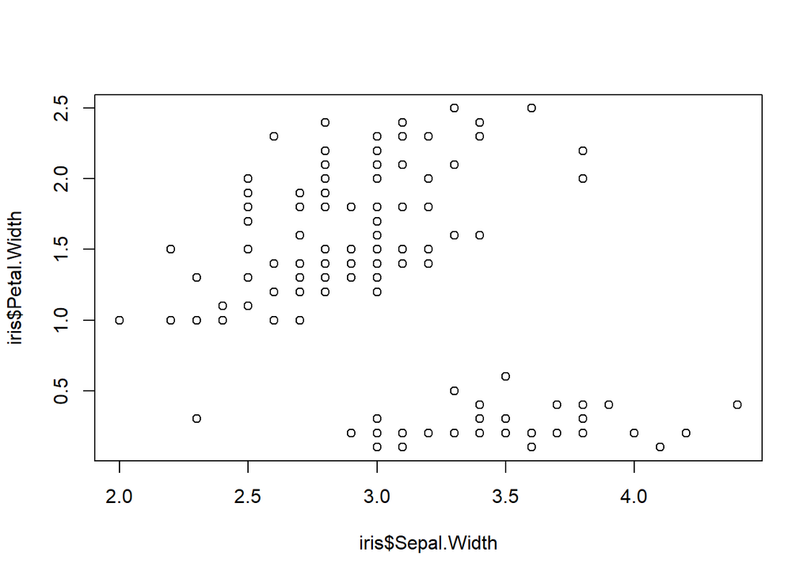

```r
plot(x=iris$Sepal.Width, y=iris$Petal.Width)
```

Mit zusätzlichen Argumenten in der Funktion kann man die Graphik verschönern und erweitern:

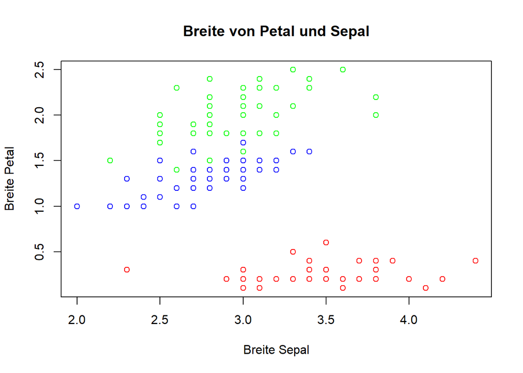

```r
plot(x=iris$Sepal.Width, y=iris$Petal.Width,
     col=c("red","blue","green")[iris$Species], # nach Spezies einfärben
    xlab="Breite Sepal", ylab="Breite Petal", main="Breite von Petal und Sepal") # Beschriftung
```

## Shiny Apps

### Shiny Apps

Shiny Apps sind browserbasierte Programme mit graphischer Nutzeroberfläche, die sich relativ leicht und schnell erstellen lassen.  
Ein Beispiel: https://shiny.rstudio.com/gallery/kmeans-example.html.

## Machine Learning

### Machine Learning

Viele Algorithmen für maschinelles Lernen sind in R verfügbar. Z.B. random forest, eine Erweiterung von Decision Trees für Klassifizierung oder Regression.

```r
library(randomForest)

rf <- randomForest(Species ~ ., data=iris)
# Das Modell sagt anhand der Maße der Blätter die Spezies voraus
rf
```

```
##
## Call:
##  randomForest(formula = Species ~ ., data = iris)
##                Type of random forest: classification
##                      Number of trees: 500
## No. of variables tried at each split: 2
##
##         OOB estimate of  error rate: 4.67%
## Confusion matrix:
##            setosa versicolor virginica class.error
## setosa         50          0         0        0.00
## versicolor      0         47         3        0.06
## virginica       0          4        46        0.08
```

```r
predict(rf, iris[75, 1:4]) # Vorhersage für Zeile 75 anhand des Modells
```

```
##         75
## versicolor
## Levels: setosa versicolor virginica
```

```r
iris[75, 5] # Wahre Klasse in Zeile 75
```

```
## [1] versicolor
## Levels: setosa versicolor virginica
```